# Exploring the BRFSS data

## Setup

### Load packages

```r
library(ggplot2)
library(dplyr)
```

### Load data

```r
load("brfss2013.RData")
```

## Part 1: Data

## Part 2: Research questions

**Research quesion 1:** How does self-reported general health differ between adults who did and did not exercise in the past 30 days, across BMI categories?

**Research quesion 2:** Among U.S. adults, how does the number of days of poor mental health in the past 30 days differ by recent exercise status and sex?

**Research quesion 3:** How does self-reported general health differ across household income categories among adults with and without health-care coverage?

## Part 3: Exploratory data analysis

**Research quesion 1:** How does self-reported general health differ between adults who did and did not exercise in the past 30 days, across BMI categories?

```r
health_exercise <- brfss2013 %>%
  select(exerany2, genhlth, X_bmi5cat) %>%
  filter(
    !is.na(exerany2),
    !is.na(genhlth),
    !is.na(X_bmi5cat)
  ) %>%
  mutate(
    exercise = factor(exerany2, levels = c("Yes", "No")),
    health = factor(
      genhlth,
      levels = c("Excellent", "Very good", "Good", "Fair", "Poor")
    ),
    bmi_category = factor(
      X_bmi5cat,
      levels = c("Underweight", "Normal weight", "Overweight", "Obese")
    )
  ) %>%
  select(exercise, health, bmi_category)

rq1_summary <- health_exercise %>%
  count(bmi_category, exercise, health) %>%
  group_by(bmi_category, exercise) %>%
  mutate(proportion = n / sum(n)) %>%
  ungroup()

rq1_summary
```

```
## # A tibble: 40 × 5
##    bmi_category exercise health        n proportion
##    <fct>        <fct>    <fct>     <int>      <dbl>
##  1 Underweight  Yes      Excellent  1270     0.248
##  2 Underweight  Yes      Very good  1577     0.308
##  3 Underweight  Yes      Good       1272     0.248
##  4 Underweight  Yes      Fair        650     0.127
##  5 Underweight  Yes      Poor        353     0.0689
##  6 Underweight  No       Excellent   252     0.102
##  7 Underweight  No       Very good   454     0.184
##  8 Underweight  No       Good        711     0.287
##  9 Underweight  No       Fair        536     0.217
## 10 Underweight  No       Poor        521     0.211
## # ℹ 30 more rows
```

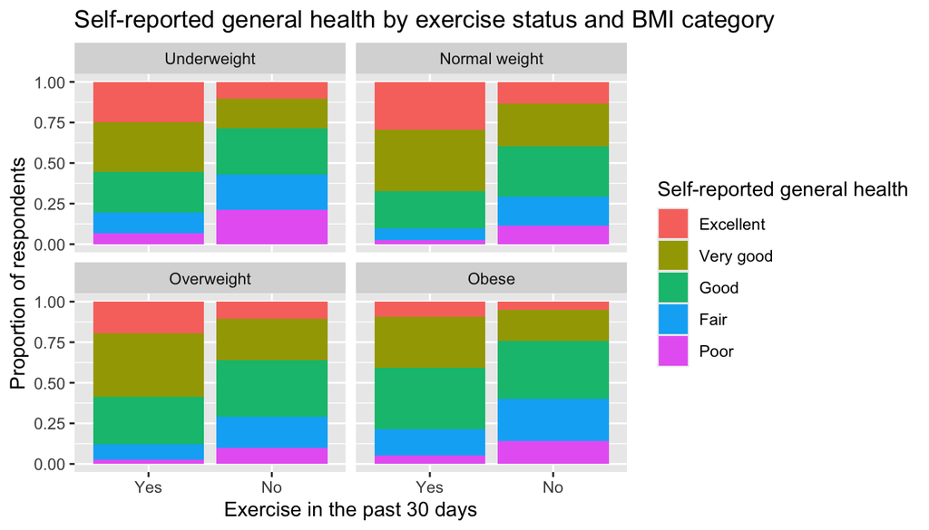

```r
ggplot(rq1_summary,
       aes(x = exercise, y = proportion, fill = health)) +
  geom_col() +
  facet_wrap(~ bmi_category) +
  labs(
    title = "Self-reported general health by exercise status and BMI category",
    x = "Exercise in the past 30 days",
    y = "Proportion of respondents",
    fill = "Self-reported general health"
  )
```

```r
rq1_numerical_summary <- health_exercise %>%
  group_by(bmi_category, exercise) %>%
  summarise(
    n = n(),
    excellent_very_good_pct = round(
      100 * mean(health %in% c("Excellent", "Very good")),
      1
    ),
    good_pct = round(
      100 * mean(health == "Good"),
      1
    ),
    fair_poor_pct = round(
      100 * mean(health %in% c("Fair", "Poor")),
      1
    ),
    .groups = "drop"
  )

rq1_numerical_summary
```

```
## # A tibble: 8 × 6
##   bmi_category  exercise      n excellent_very_good_pct good_pct fair_poor_pct
##   <fct>         <fct>     <int>                   <dbl>    <dbl>         <dbl>
## 1 Underweight   Yes        5122                    55.6     24.8          19.6
## 2 Underweight   No         2474                    28.5     28.7          42.7
## 3 Normal weight Yes      113202                    67.4     22.7           9.9
## 4 Normal weight No        30902                    39.8     30.8          29.4
## 5 Overweight    Yes      117184                    58.6     29.3          12.1
## 6 Overweight    No        38769                    36.3     34.5          29.2
## 7 Obese         Yes       81633                    40.7     37.9          21.4
## 8 Obese         No        45083                    24.3     35.6          40.1
```

The 2013 Behavioral Risk Factor Surveillance System (BRFSS) is a probability-based telephone survey of non-institutionalized U.S. adults aged 18 years and older. For this analysis, respondents with missing information on exercise, self-reported general health, or BMI category were excluded. The distribution of self-reported general health differed by both exercise status in the past 30 days and BMI category. Across all BMI categories, respondents who reported exercising had a higher proportion reporting Excellent or Very good health and a lower proportion reporting Fair or Poor health than those who did not exercise. For example, among respondents with normal weight, 67.4% of exercisers reported Excellent or Very good health, compared with 39.8% of non-exercisers. The obese group showed the least favorable health distribution overall: 40.1% of non-exercisers reported Fair or Poor health, compared with 21.4% of exercisers. These findings may be cautiously generalized to non-institutionalized U.S. adults, but potential bias may arise from nonresponse, telephone undercoverage, self-reported measures of exercise, health, height, and weight, and the exclusion of missing responses. As BRFSS is an observational survey without random assignment, the findings describe associations and do not establish that exercise causes better self-reported health.

**Research quesion 2:** Among U.S. adults, how does the number of days of poor mental health in the past 30 days differ by recent exercise status and sex?

```r
grep("menthlth|sex",
     names(brfss2013),
     value = TRUE,
     ignore.case = TRUE)
```

```
## [1] "menthlth"  "sex"       "X_impcsex"
```

```r
brfss2013 %>%
  select(menthlth, exerany2, sex) %>%
  summary()
```

```
##     menthlth        exerany2         sex
##  Min.   :   0.000   Yes:332464   Male  :201313
##  1st Qu.:   0.000   No :125282   Female:290455
##  Median :   0.000   NAs: 34029   NAs   :     7
##  Mean   :   3.383
##  3rd Qu.:   2.000
##  Max.   :5000.000
##  NAs    :8627
```

```r
table(brfss2013$sex, useNA = "ifany")
```

```
##
##   Male Female   <NA>
## 201313 290455      7
```

```r
table(brfss2013$menthlth, useNA = "ifany")
```

```
##
##      0      1      2      3      4      5      6      7      8      9     10
## 334461  15206  23520  13593   6660  16654   1861   6353   1244    198  11917
##     11     12     13     14     15     16     17     18     19     20     21
##     74    812     97   2516  10910    161    105    181     45   6633    497
##     22     23     24     25     26     27     28     29     30    247   5000
##    113     61     87   2318     89    164    680    415  25521      1      1
##   <NA>
##   8627
```

```r
mental_health_exercise <- brfss2013 %>%
  select(menthlth, exerany2, sex) %>%
  filter(
    !is.na(menthlth),
    !is.na(exerany2),
    !is.na(sex),
    menthlth >= 0,
    menthlth <= 30
  ) %>%
  mutate(
    exercise = factor(exerany2, levels = c("Yes", "No")),
    sex = factor(sex, levels = c("Male", "Female"))
  ) %>%
  select(menthlth, exercise, sex)

summary(mental_health_exercise$menthlth)
```

```
##    Min. 1st Qu.  Median    Mean 3rd Qu.    Max.
##   0.000   0.000   0.000   3.365   2.000  30.000
```

```r
table(mental_health_exercise$sex)
```

```
##
##   Male Female
## 183724 266347
```

```r
table(mental_health_exercise$exercise)
```

```
##
##    Yes     No
## 327772 122299
```

```r
rq2_summary <- mental_health_exercise %>%
  group_by(sex, exercise) %>%
  summarise(
    n = n(),
    median_days = median(menthlth),
    iqr_days = IQR(menthlth),
    mean_days = round(mean(menthlth), 1),
    zero_days_pct = round(100 * mean(menthlth == 0), 1),
    .groups = "drop"
  )

rq2_summary
```

```
## # A tibble: 4 × 7
##   sex    exercise      n median_days iqr_days mean_days zero_days_pct
##   <fct>  <fct>     <int>       <dbl>    <dbl>     <dbl>         <dbl>
## 1 Male   Yes      137862           0        0       2.4          75.4
## 2 Male   No        45862           0        2       4            71.3
## 3 Female Yes      189910           0        2       3.2          66.7
## 4 Female No        76437           0        5       5.2          62.1
```

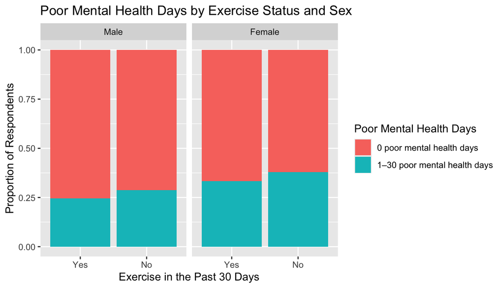

```r
rq2_plot_data <- mental_health_exercise %>%
  mutate(
    mental_health_status = if_else(
      menthlth == 0,
      "0 poor mental health days",
      "1–30 poor mental health days"
    )
  ) %>%
  count(sex, exercise, mental_health_status) %>%
  group_by(sex, exercise) %>%
  mutate(proportion = n / sum(n)) %>%
  ungroup()

ggplot(
  rq2_plot_data,
  aes(x = exercise, y = proportion, fill = mental_health_status)
) +
  geom_col() +
  facet_wrap(~ sex) +
  labs(
    title = "Poor Mental Health Days by Exercise Status and Sex",
    x = "Exercise in the Past 30 Days",
    y = "Proportion of Respondents",
    fill = "Poor Mental Health Days"
  )
```

Respondents who reported exercising in the past 30 days were more likely to report zero poor mental health days than those who did not exercise, among both males and females. Female respondents had a lower proportion of zero poor mental health days than male respondents regardless of exercise status. The most favorable distribution was observed among male exercisers, whereas female non-exercisers had the highest proportion reporting one or more poor mental health days.

**Research quesion 3:** How does self-reported general health differ across household income categories among adults with and without health-care coverage?

```r
grep("hlthpln|income|genhlth",
     names(brfss2013),
     value = TRUE,
     ignore.case = TRUE)
```

```
## [1] "genhlth"  "hlthpln1" "income2"
```

```r
brfss2013 %>%
  select(genhlth, hlthpln1, income2) %>%
  summary()
```

```
##       genhlth       hlthpln1                  income2
##  Excellent: 85482   Yes:434571   $75,000 or more  :115902
##  Very good:159076   No : 55300   Less than $75,000: 65231
##  Good     :150555   NAs:  1904   Less than $50,000: 61509
##  Fair     : 66726                Less than $35,000: 48867
##  Poor     : 27951                Less than $25,000: 41732
##  NAs      :  1985                (Other)          : 87108
##                                  NAs              : 71426
```

```r
table(brfss2013$hlthpln1, useNA = "ifany")
```

```
##
##    Yes     No   <NA>
## 434571  55300   1904
```

```r
table(brfss2013$income2, useNA = "ifany")
```

```
##
## Less than $10,000 Less than $15,000 Less than $20,000 Less than $25,000
##             25441             26794             34873             41732
## Less than $35,000 Less than $50,000 Less than $75,000   $75,000 or more
##             48867             61509             65231            115902
##              <NA>
##             71426
```

```r
table(brfss2013$genhlth, useNA = "ifany")
```

```
##
## Excellent Very good      Good      Fair      Poor      <NA>
##     85482    159076    150555     66726     27951      1985
```

```r
rq3_data <- brfss2013 %>%
  select(genhlth, hlthpln1, income2) %>%
  filter(
    !is.na(genhlth),
    !is.na(hlthpln1),
    !is.na(income2)
  ) %>%
  mutate(
    income_group = case_when(
      income2 %in% c(
        "Less than $10,000",
        "Less than $15,000",
        "Less than $20,000",
        "Less than $25,000"
      ) ~ "Less than $25,000",

      income2 %in% c(
        "Less than $35,000",
        "Less than $50,000",
        "Less than $75,000"
      ) ~ "$25,000 to less than $75,000",

      income2 == "$75,000 or more" ~ "$75,000 or more"
    )
  ) %>%
  mutate(
    health = factor(
      genhlth,
      levels = c("Excellent", "Very good", "Good", "Fair", "Poor")
    ),
    insurance = factor(
      hlthpln1,
      levels = c("Yes", "No")
    ),
    income_group = factor(
      income_group,
      levels = c(
        "Less than $25,000",
        "$25,000 to less than $75,000",
        "$75,000 or more"
      )
    )
  ) %>%
  select(health, insurance, income_group)

nrow(rq3_data)
```

```
## [1] 418036
```

```r
table(rq3_data$insurance)
```

```
##
##    Yes     No
## 370777  47259
```

```r
table(rq3_data$income_group)
```

```
##
##            Less than $25,000 $25,000 to less than $75,000
##                       127668                       174812
##              $75,000 or more
##                       115556
```

```r
table(rq3_data$health)
```

```
##
## Excellent Very good      Good      Fair      Poor
##     74113    138003    127380     55486     23054
```

```r
rq3_summary <- rq3_data %>%
  group_by(insurance, income_group) %>%
  summarise(
    n = n(),
    excellent_very_good_pct = round(
      100 * mean(health %in% c("Excellent", "Very good")),
      1
    ),
    good_pct = round(
      100 * mean(health == "Good"),
      1
    ),
    fair_poor_pct = round(
      100 * mean(health %in% c("Fair", "Poor")),
      1
    ),
    .groups = "drop"
  )
rq3_summary
```

```
## # A tibble: 6 × 6
##   insurance income_group         n excellent_very_good_…¹ good_pct fair_poor_pct
##   <fct>     <fct>            <int>                  <dbl>    <dbl>         <dbl>
## 1 Yes       Less than $25,…  99362                   30.1     32.6          37.4
## 2 Yes       $25,000 to les… 158617                   52.6     32.6          14.8
## 3 Yes       $75,000 or more 112798                   70.5     23.6           5.9
## 4 No        Less than $25,…  28306                   33.5     36.4          30.1
## 5 No        $25,000 to les…  16195                   49.7     35.3          15.1
## 6 No        $75,000 or more   2758                   63.9     27.9           8.3
## # ℹ abbreviated name: ¹excellent_very_good_pct
```

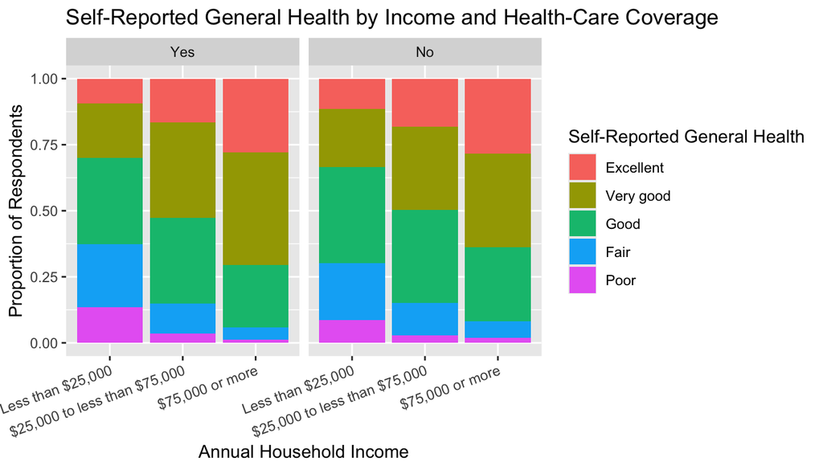

```r
rq3_plot_data <- rq3_data %>%
  count(insurance, income_group, health) %>%
  group_by(insurance, income_group) %>%
  mutate(proportion = n / sum(n)) %>%
  ungroup()

ggplot(
  rq3_plot_data,
  aes(x = income_group, y = proportion, fill = health)
) +
  geom_col() +
  facet_wrap(~ insurance) +
  labs(
    title = "Self-Reported General Health by Income and Health-Care Coverage",
    x = "Annual Household Income",
    y = "Proportion of Respondents",
    fill = "Self-Reported General Health"
  ) +
  theme(axis.text.x = element_text(angle = 20, hjust = 1))
```

Self-reported general health showed a clear income gradient within both health-care coverage groups. Among respondents with coverage, the proportion reporting Excellent or Very good health increased from 30.1% in the lowest income group to 70.5% in the highest income group, while the Fair or Poor proportion decreased from 37.4% to 5.9%. A similar pattern appeared among respondents without coverage: Excellent or Very good health increased from 33.5% to 63.9%, and Fair or Poor health decreased from 30.1% to 8.3% across the same income groups.

The relationship between insurance coverage and self-reported health was not consistent within each income group. For example, low-income respondents without coverage reported a somewhat more favorable health distribution than low-income respondents with coverage. This pattern should not be interpreted as evidence that lacking coverage is beneficial; it may reflect differences in age, existing health needs, employment, or other unmeasured characteristics. In addition, the high-income uninsured group was relatively small (n = 2,758), so that comparison should be interpreted cautiously. Because BRFSS is observational, these findings describe associations rather than causal effects.